# Curso de R Nivel Básico

Luis Manuel Rodarte Solórzano

January 02, 2023

# 1. Introducción a R

## 1.1. Aritmética Básica

En el lenguaje R, las cuatro operaciones básicas de la aritmética se representan con los símbolos $+$ (suma), $−$ (resta), ∗ (multiplicación) y / (división). Por ejemplo, para realizar la suma de uno más dos en R, basta con escribir en la consola `1+2`, luego dar clic en la tecla Enter. El siguiente ejemplo, ilustra la suma de uno más dos en R.

```r
### Aritmética Básica

# Suma
1+2
```

```
## [1] 3
```

Al realizar la resta de seis menos dos en la consola de R, se debe de escribir `6−2`, tal como se muestra en el siguiente código:

```r
# Resta
6-2
```

```
## [1] 4
```

```r
# Multiplicación
5*7
```

```
## [1] 35
```

```r
# División
50/15
```

```
## [1] 3.333333
```

En R, para realizar la operación $5^2$, se escribe `5^2` en la consola. Por ejemplo, al escribir `(2-3+10)^2` en la consola y ejecutar el código, el resultado es 81. Realice la operación $\left(\dfrac{1+3*5}{8-13}\right)^5$

```r
# Potencia
((1+3*5)/(8-13))^5
```

```
## [1] -335.5443
```

Para obtener la raíz cuadrada de un número en R, se utiliza la función nombrada `sqrt()`. En particular, para obtener la raíz cuadrada de 112358, se escribe `sqrt(112358)` en la consola. Realice la operación $\sqrt{\left(\dfrac{2*3+21}{55-34}\right)^3}$

```r
# Raíz cuadrada
sqrt(((2*3+21)/(55-34))**3)
```

```
## [1] 1.457863
```

```r
sqrt(((2*3+21)/(55-34))^3)
```

```
## [1] 1.457863
```

## 1.2. Operadores comparativos

### 1.2.1. Símbolos < y >

```r
## Operadores comparativos
3/14 < 6/25
```

```
## [1] TRUE
```

```r
1/55 > 2/34
```

```
## [1] FALSE
```

### 1.2.2. Otros símbolos

En la siguiente tabla, se presentan otros operadores comparativos que se utilizan en R.

| **Símbolo** | **Comando de R** | **Ejemplo** |
| --- | --- | --- |
| ≤ | `<=` | `1<=3` |
| ≥ | `>=` | `15>=3` |
| = | `==` | `6==3` |
| ≠ | `!=` | `1!=7` |

## 1.3. Tipos de Datos

### 1.3.1. Logical

En R existen tres tipos de datos básicos, los cuales son: logical, numeric y character. Los de tipo **logical** son únicamente TRUE y FALSE. Los **numeric** son los números reales, por ejemplo, 1.2, 100, 0.00002,…, etc. Los de tipo **character** son las cadenas de texto declaradas entre comillas dobles o simples, por ejemplo, `"Hola Mundo"` o `'Hola Mundo'`.

## 1.4. Operadores Lógicos

Los operadores lógicos en R se utilizan para representar operaciones de algebra Booleana, es decir, para describir relaciones lógicas expresadas en términos de `FALSE` o `TRUE`. En la siguiente tabla se muestran las diferentes operaciones Booleanas.

| **Operador** | **Comparación** | **Ejemplo** | **Resultado** |
| --- | --- | --- | --- |
| `!x` | x no es verdadero (Negación) | `!FALSE` | `TRUE` |
| `isTRUE` | x es verdadero (Afirmación) | `isTRUE(TRUE)` | `TRUE` |
| `x\|y` | x ó y es verdadero | `FALSE \| TRUE` | `TRUE` |
| `x & y` | x y y son verdaderos | `TRUE & FALSE` | `FALSE` |

Las leyes de asignación de los operadores $|$ y $&$ son las siguientes:

- `&` retorna `TRUE` si y solo si ambos datos son `TRUE`
- `&` retorna `FALSE` si alguno de los datos es `FALSE`
- `|` retorna `TRUE` si alguno de los datos es `TRUE`
- `|` retorna `FALSE` si y solo si ambos datos son `FALSE`

## 1.5. Declaración de variables

En R existen tres formas de declarar variables y para el nombre de las variables se pueden utilizar las letras mayúsculas de la A-Z, las minúsculas de la a-z y los números del 0-9, teniendo en cuenta que el nombre de una variable nunca debe de iniciar con un número. A continuación, se presentan las tres forma de declarar variables en R.

```r
# Tipo 1
x1 <- 1

# Tipo 2
x2 = 2

# Tipo 3
3 -> x3
```

Para conocer qué tipo de dato es una variable, se utiliza la función `class()`, la cual retorna el nombre de la clase a la que pertenece el dato asignado a la variable, y para verificar si una variable es de un tipo específico de dato, se utilizan las funciones `is.character()`, `is.logical()` y `is.numeric()`. Por ejemplo:

```r
# Tipos de variables
z = 5
class(z)   # imprime a que clase (tipo) pertenece z
```

```
## [1] "numeric"
```

```r
z1 <- "Todos tenemos un secreto escondido bajo llave en el ático del alma."

class(z1)
```

```
## [1] "character"
```

```r
is.logical(z1)   # ¿z1 es de tipo logical?
```

```
## [1] FALSE
```

```r
is.character(z1)  # ¿z1 es de tipo character?
```

```
## [1] TRUE
```

```r
z2 <- "TRUE"
is.logical(z2)    # ¿z2 es de tipo logical?
```

```
## [1] FALSE
```

```r
z3 <- TRUE
is.logical(z3)    # ¿z3 es de tipo logical?
```

```
## [1] TRUE
```

```r
z4 <- 42.5
is.numeric(z4)    # ¿z3 es de tipo numeric?
```

```
## [1] TRUE
```

# 2. Tipos de Objetos en R

## 2.1. Vectores

Para declarar un vector en R, se utiliza la palabra reservada `c` y seguido de la letra “c” en paréntesis se escriben los elementos del vector separados por coma. Por ejemplo:

```r
# Declarar un vector
v <- c(0,1,1,2,3,5,8,13,21,34)
# Forma para declarar un vector c(elemento1, elemento 2,...)

v # Vector v
```

```
##  [1]  0  1  1  2  3  5  8 13 21 34
```

Para calcular la media aritmética de un vector que contiene datos de tipo numeric, se utiliza la función `mean()`, entre los paréntesis se ubica el vector, por ejemplo:

```r
# Función mean()
mean(v)  # Retorna la media aritmética de los datos {0,1,1,2,3,5,8,13,21,34}
```

```
## [1] 8.8
```

Para calcular la suma de los elementos de un vector que contiene datos de tipo numeric, se utiliza la función `sum()`, por ejemplo:

```r
# Función sum()
sum(v)   # Retorna la suma de los datos {0,1,1,2,3,5,8,13,21,34}
```

```
## [1] 88
```

Para calcular la desviación estándar de los elementos de un vector que contiene datos de tipo numeric, se utiliza la función `sd()`, por ejemplo:

```r
# Función sd()
sd(v)      # Retorna la desviación estándar de los elementos del vector v
```

```
## [1] 11.03328
```

En R se pueden hacer operaciones entre vectores, siempre y cuando los vectores tengan la misma cantidad de elementos. Sean los vectores:

```r
# Algunas operaciones
p <- c(1,2,3,4)
p
```

```
## [1] 1 2 3 4
```

```r
q <- c(2,4,6,8)
q
```

```
## [1] 2 4 6 8
```

```r
# Suma
p+q   # Retorna la suma elemento a elemento de los vectores
```

```
## [1]  3  6  9 12
```

```r
# Resta
p-q    # Retorna la resta elemento a elemento de los vectores
```

```
## [1] -1 -2 -3 -4
```

```r
# Multiplicación
p*q    # Retorna la multiplicación elemento a elemento de los vectores
```

```
## [1]  2  8 18 32
```

## 2.2. Matrices

### 2.2.1. Declarar matrices

Existen dos formas para declarar matrices en R, una es por columnas y otra es por filas. A continuación, se presentan ambos casos; considere la matriz $A=\begin{equation} \begin{bmatrix} 1 & 1 & 2\\ 3 & 5 & 8\\ 13 & 21 & 34 \end{bmatrix} \end{equation}$

```r
# Datos ordenados por columnas
d1 <- c(1,3,13,1,5,21,2,8,34)

# Datos ordenados por filas
d2 <- c(1,1,2,3,5,8,13,21,34)
```

El vector `d1` se utiliza para declarar la matriz por columnas, y el vector `d2` para declarar la matriz por filas. Se utiliza la función `matrix()` para declarar una matriz, esta función tiene varios parámetros: el primero es `data`, y hace referencia al vector que contiene los datos de la matriz; el segundo es `nrow`, e indica el número de filas que contiene la matriz, el tercero es `ncol`, e indica el número de columnas que contiene la matriz; y el último es `byrow` e indica si el vector `data` está ordenado por filas o columnas

#### Por Columnas

Para declarar una matriz por columnas, se ordena el vector `data` por columnas y el valor del parámetro `byrow` debe ser `FALSE`, para hacer referencia de que el vector `data` está ordenado por columnas.

```r
A1 <- matrix(data = d1, nrow = 3, ncol = 3, byrow = FALSE)
A1
```

```
##      [,1] [,2] [,3]
## [1,]    1    1    2
## [2,]    3    5    8
## [3,]   13   21   34
```

#### Por Filas

Para declarar una matriz por filas, se ordena el vector `data` por filas y el valor del parámetro `byrow` debe ser `TRUE`, para hacer referencia de que el vector `data` está ordenado por filas.

```r
A2 <- matrix(data = d2, nrow = 3, ncol = 3, byrow = TRUE)
A2
```

```
##      [,1] [,2] [,3]
## [1,]    1    1    2
## [2,]    3    5    8
## [3,]   13   21   34
```

### 2.2.2. Operaciones con matrices

En R se pueden hacer operaciones de summa y resta entre matrices, siempre y cuando las matrices tengan las mismas dimensiones.

```r
A <- matrix(data = c(1,2,2,4,2,1), nrow = 3, ncol = 2, byrow = FALSE)
A
```

```
##      [,1] [,2]
## [1,]    1    4
## [2,]    2    2
## [3,]    2    1
```

```r
B <- matrix(data = c(5,4,6,1,8,9), nrow = 3, ncol = 2, byrow = FALSE)
B
```

```
##      [,1] [,2]
## [1,]    5    1
## [2,]    4    8
## [3,]    6    9
```

A continuación se muestra la suma y la resta:

```r
# Suma
A+B
```

```
##      [,1] [,2]
## [1,]    6    5
## [2,]    6   10
## [3,]    8   10
```

```r
# Resta
A-B
```

```
##      [,1] [,2]
## [1,]   -4    3
## [2,]   -2   -6
## [3,]   -4   -8
```

La multiplicación de una matriz *A* por una matriz *B* es posible siempre y cuando el número de columnas de *A* coincida con el número de filas de *B*.

Condideremos las siguientes matrices:

$A=\begin{equation} \begin{bmatrix} 1 & 1 & 2\\ 3 & 5 & 8 \end{bmatrix} \end{equation}$ y $B=\begin{equation} \begin{bmatrix} 13 & 55 \\ 21 & 89 \\ 34 & 144 \end{bmatrix} \end{equation}$

```r
C <- matrix(data = c(1,3,1,5,2,8), nrow = 2, ncol = 3, byrow = FALSE)
C
```

```
##      [,1] [,2] [,3]
## [1,]    1    1    2
## [2,]    3    5    8
```

```r
D <- matrix(data = c(13,21,34,55,89,144), nrow = 3, ncol = 2, byrow = FALSE)
D
```

```
##      [,1] [,2]
## [1,]   13   55
## [2,]   21   89
## [3,]   34  144
```

Dado que el número de columnas de *C* es igual al número de filas de *D*, entonces es posible multiplicar *C* por *D*, así que el resultado es:

```r
# Multi plicación de las matrices
C %*% D
```

```
##      [,1] [,2]
## [1,]  102  432
## [2,]  416 1762
```

Note que para multiplicar dos matrices, se utiliza el operador`%*%`.

## 2.3. Listas

### 2.3.1. Declarar una lista

Las listas en R son estructuras de fdatos que permiten almacenar diferentes tipos de variables. Para declarar una lista en R, se utiliza la función `list()`, y entre paréntesis se escriben las variables separadas por coma, como se muestra a continuación:

```r
nombre.de.lista <- list(a = "Buongiorno principessa", b = 42,
                        c = TRUE, d = c(1,2,3,4,5))
nombre.de.lista
```

```
## $a
## [1] "Buongiorno principessa"
##
## $b
## [1] 42
##
## $c
## [1] TRUE
##
## $d
## [1] 1 2 3 4 5
```

Para obtener ñps valores de la lista, se escribe el nombre de la lista seguido el símbolo de pesos ($) y luego el nombre de la variable; como se muestra a continuación:

```r
nombre.de.lista$a   # Se obtiene el valor de a
```

```
## [1] "Buongiorno principessa"
```

```r
nombre.de.lista$b   # Se obtiene el valor de b
```

```
## [1] 42
```

```r
nombre.de.lista$c   # Se obtiene el valor de c
```

```
## [1] TRUE
```

```r
nombre.de.lista$d   # Se obtiene el valor de d
```

```
## [1] 1 2 3 4 5
```

## 2.4. Data frame

### 2.4.1. Declaración de data frame

Los data frame som estructuras de datos de dos dimensiones (rectangulares) que pueden contener datos de diferentes tipos. Generalmente se utiliza para el análisis de datos y su estructura es familiar a otros paquetes estadísticos. Para declarar un data frame, se utiliza la función `data.frame` y entre paréntesis se escriben las columnas que contendrá separadas por coma; como se muestra a continuación:

```r
nombre.de.data.frame <- data.frame(nombre.columna1 = c(1,2,3,4,5),
                                   nombre.columna2 =
                                     c("Juanma","Braulio","Luis","Alejandro","Pedro"),
                                   nombre.columna3 = c(FALSE,TRUE,FALSE,TRUE,FALSE))

nombre.de.data.frame
```

```
##   nombre.columna1 nombre.columna2 nombre.columna3
## 1               1          Juanma           FALSE
## 2               2         Braulio            TRUE
## 3               3            Luis           FALSE
## 4               4       Alejandro            TRUE
## 5               5           Pedro           FALSE
```

Para obtener los valores de las columnas, se escribe el nombre del data frame seguido el símbolo de pesos `$` y luego el nombre de la columna.

```r
nombre.de.data.frame$nombre.columna1  # Se obtiene el valor de nombre.columna1
```

```
## [1] 1 2 3 4 5
```

```r
nombre.de.data.frame$nombre.columna2  # Se obtiene el valor de nombre.columna2
```

```
## [1] "Juanma"    "Braulio"   "Luis"      "Alejandro" "Pedro"
```

```r
nombre.de.data.frame$nombre.columna3  # Se obtiene el valor de nombre.columna3
```

```
## [1] FALSE  TRUE FALSE  TRUE FALSE
```

### 2.4.2. Selección de datos usando operadores comparativos

Sea el siguiente data frame

```r
nombre.de.data.frame <- data.frame(nombre.columna1 = c(1,2,3,4,5),
                                   nombre.columna2 = c("Juanma","Braulio","Luis",
                                                       "Alejandro","Pedro"),
                                   nombre.columna3 = c(FALSE,TRUE,FALSE,TRUE,FALSE))

nombre.de.data.frame
```

```
##   nombre.columna1 nombre.columna2 nombre.columna3
## 1               1          Juanma           FALSE
## 2               2         Braulio            TRUE
## 3               3            Luis           FALSE
## 4               4       Alejandro            TRUE
## 5               5           Pedro           FALSE
```

Para buscar observaciones específicas en R, se utilizan los operdores comparativos. Por ejemplo, para buscar aquellas observaciones en las cuales la variable `nombre.columna1` sea mayor que 3, se utiliza el siguiente código:

```r
# Se obtienen los datos u observaciones en los que nombre.columna1 sean mayores que 3
nombre.de.data.frame[nombre.de.data.frame$nombre.columna1 > 3, ]
```

```
##   nombre.columna1 nombre.columna2 nombre.columna3
## 4               4       Alejandro            TRUE
## 5               5           Pedro           FALSE
```

Para buscar aquellas observaciones en las cuales la variable `nombre.columna2` sea igual a “Juanma”, se utiliza el siguiente código:

```r
# Se obtienen las obswrvaciones cuyo valor de nombre.columna2 sea igual a Juanma
nombre.de.data.frame[nombre.de.data.frame$nombre.columna2 == "Juanma", ]
```

```
##   nombre.columna1 nombre.columna2 nombre.columna3
## 1               1          Juanma           FALSE
```

Para buscar aquellas observaciones en las cuales la variable `nombre.columna3` sea igual a `TRUE`, se utiliza el siguiente código:

```r
# Se obtienen las observaciones o datos cuya variable nombre.columna3 sea igual a TRUE
nombre.de.data.frame[nombre.de.data.frame$nombre.columna3 == TRUE, ]
```

```
##   nombre.columna1 nombre.columna2 nombre.columna3
## 2               2         Braulio            TRUE
## 4               4       Alejandro            TRUE
```

# 3. Funciones

## 3.1. Mi primera función

### 3.1.1. Declarar una función

```r
nombre_de_funcion <- function(){
  print("Si me dejas estaré encantado de ser parte de tu biografía")
}

nombre_de_funcion()   # Se ejecuta la función declarada
```

```
## [1] "Si me dejas estaré encantado de ser parte de tu biografía"
```

# 4. Gráficos

## 4.1. Función `plot()`

### 4.1.1. Declarar ejes x y y

En R la función `plot()` se usa de manera general para crear gráficos. Para ello, es necesario definir los siguientes argumentos:

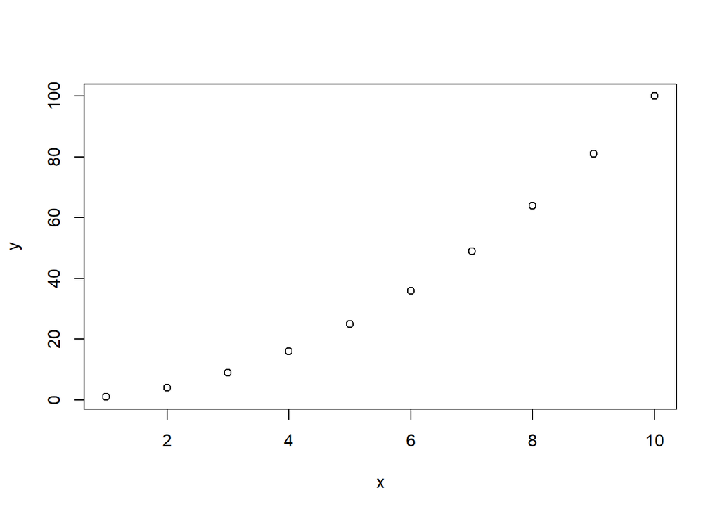

```r
# Representará el eje x del plano cartesiano
x <- c(1,2,3,4,5,6,7,8,9,10)

# Representará el eje y del plano cartesiano
y <- c(1,4,9,16,25,36,49,64,81,100)

plot(x, y)
```

### 4.1.2. Tipo de gráfico

Se pueden escoger diferentes tipos de gráficos utilizando las siguientes sintaxis:

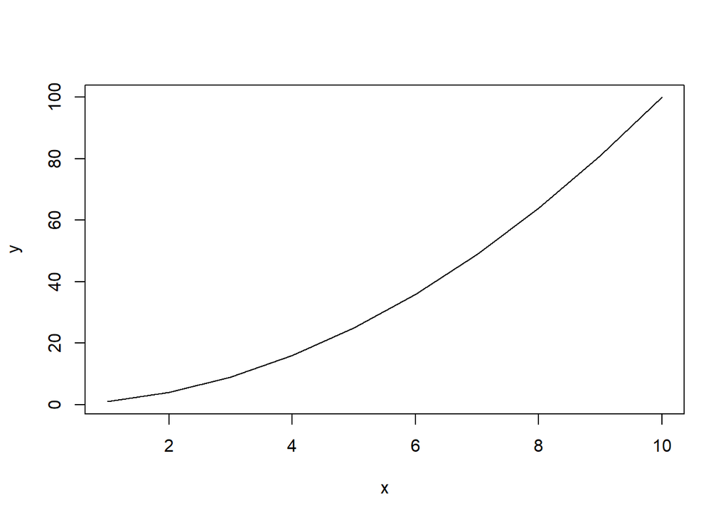

```r
plot(x, y, type = "l")   # Tipo l
```

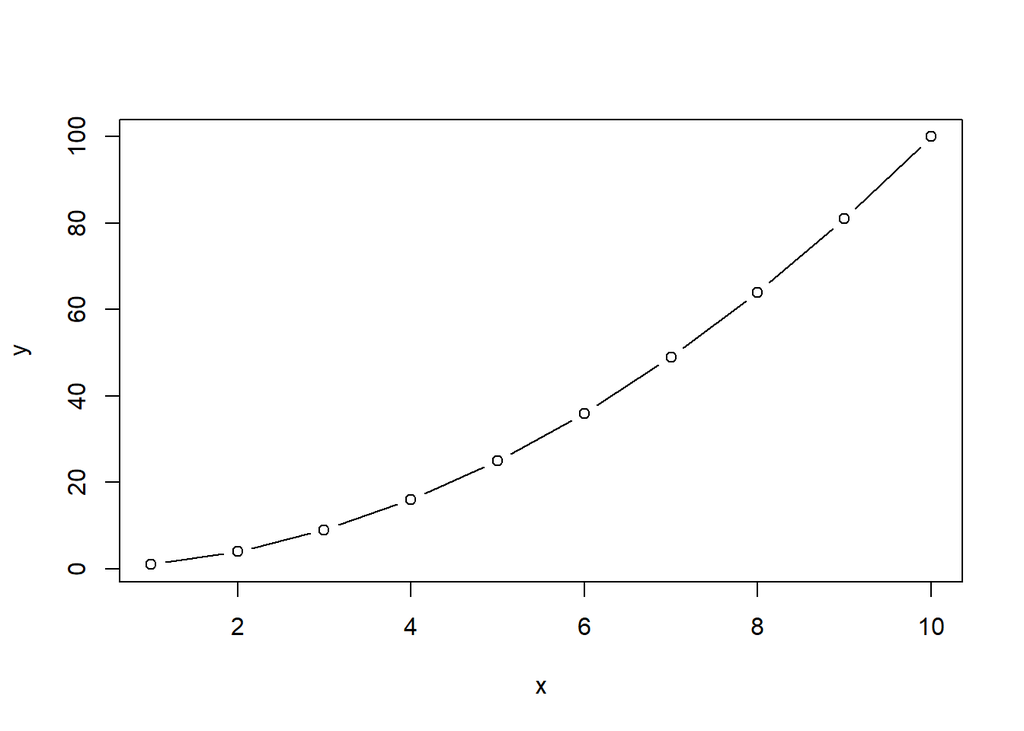

```r
plot(x, y, type = "b")   # Tipo b
```

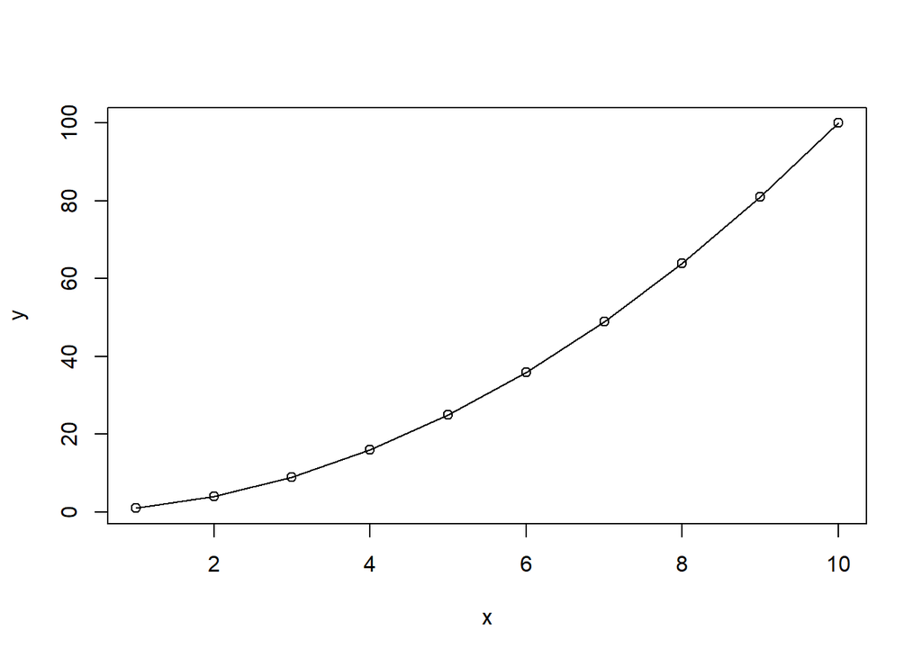

```r
plot(x, y, type = "o")   # Tipo o
```

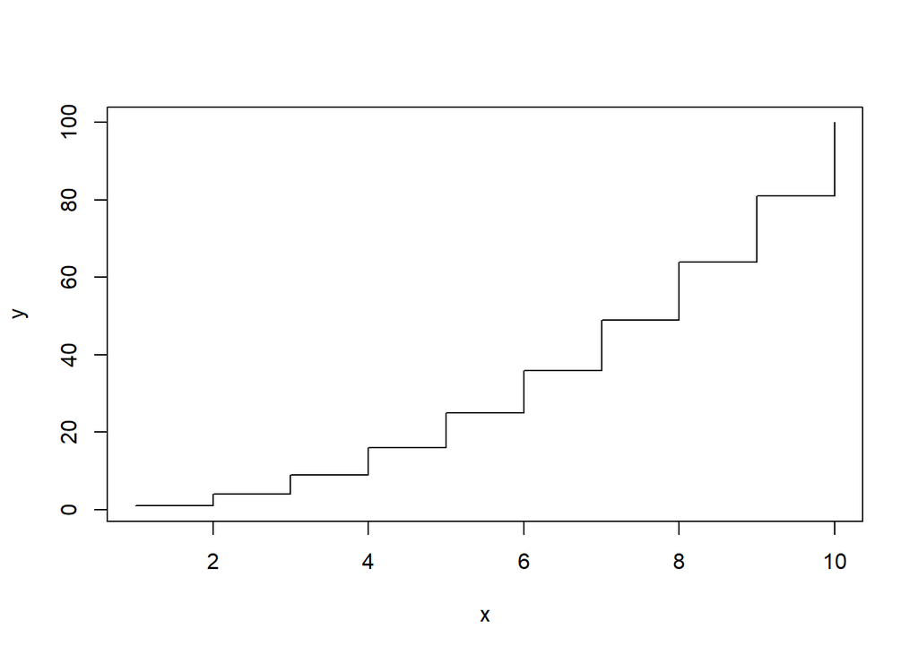

```r
plot(x, y, type = "s")   # Tipo s
```

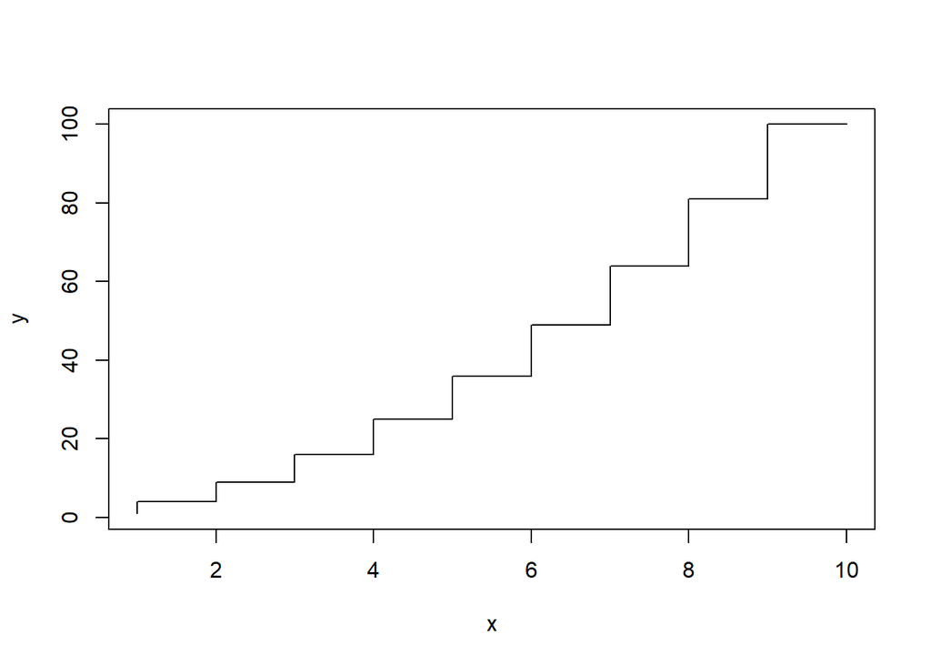

```r
plot(x, y, type = "S")   # Tipo S
```

### 4.1.3. Agregar texto a la gráfica

Para agregar texto a la gráfica, se utiliza los parámetros “main” para el título del gráfico, “sub” para el subtítulo del gráfico, “xlab” nombre del eje x y “ylab” nombre del eje y. El código para visualizar un gráfico con texto es el siguiente:

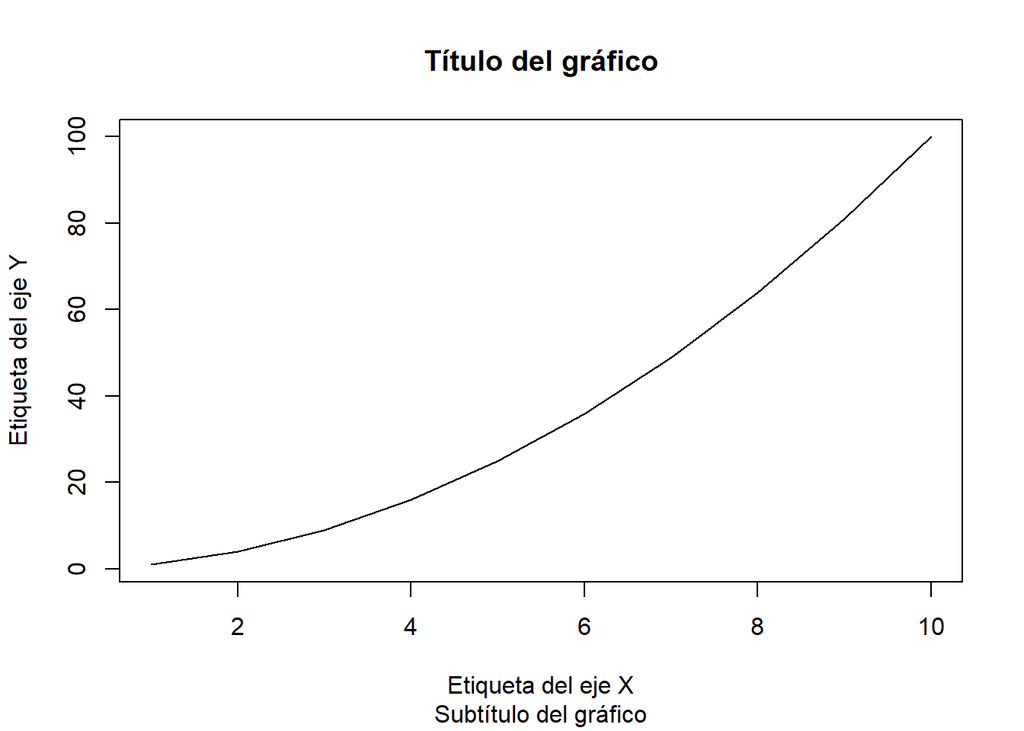

```r
plot(x, y, type = "l", main = "Título del gráfico",
     sub = "Subtítulo del gráfico", xlab = "Etiqueta del eje X",
     ylab = "Etiqueta del eje Y")
```

## 4.2. Función `barplot()`

La función `barplot()`, se utiliza para realizar gráficos de barra. Esta gráfica nos muestra la frecuencia con la que se han observado los datos de una variable discreta. Suponga que se tienen 34 acciones de Microsoft y 21 acciones de Apple.

| **Empresa o Compañía** | **Títulos o acciones** |
| --- | --- |
| MICROSOFT | 34 |
| APPLE | 21 |

Para realizar el gráfico de barras se escribe el siguiente código:

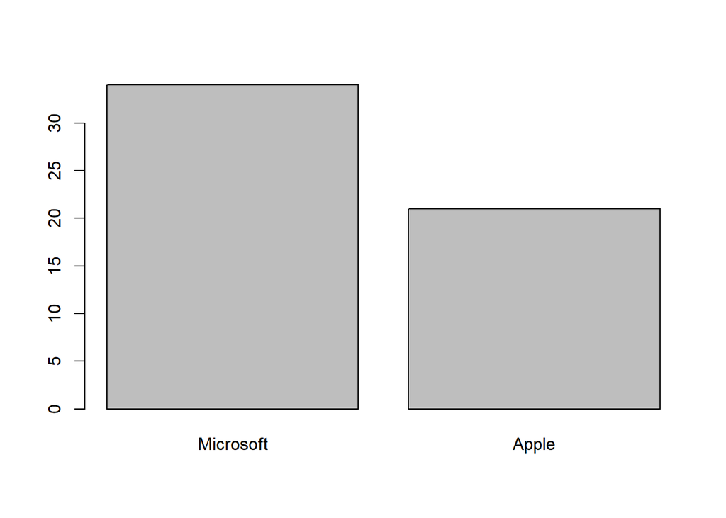

```r
barplot(c(34, 21), names.arg = c("Microsoft", "Apple"))
```

### 4.2.1. Agregar texto a la gráfica

Para agregar texto a la gráfica, se utiliza los parámetros “main” para el título del gráfico, “sub” para el subtítulo del gráfico, “xlab” nombre del eje x y “ylab” nombre del eje y. En el siguiente código se visualiza un gráfico con texto:

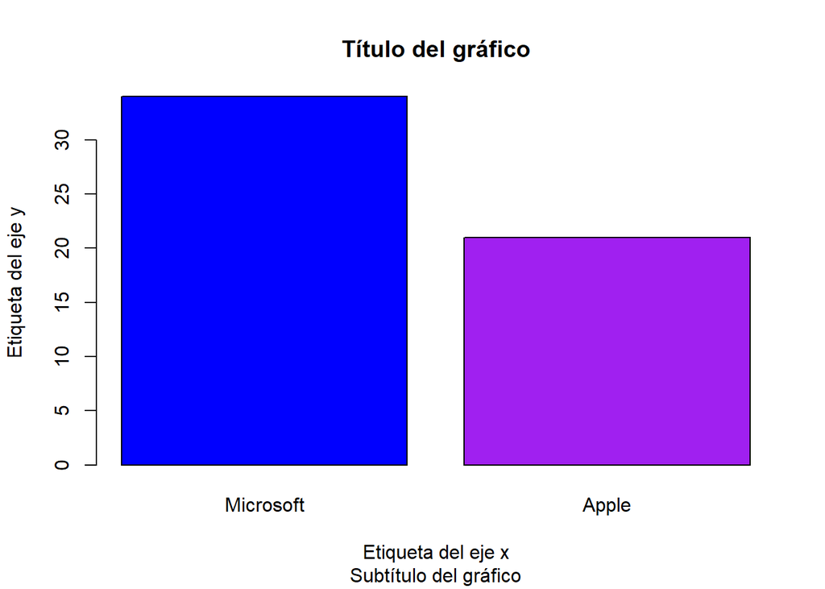

```r
barplot(c(34, 21), names.arg = c("Microsoft", "Apple"),
        main = "Título del gráfico", sub = "Subtítulo del gráfico",
        xlab = "Etiqueta del eje x", ylab = "Etiqueta del eje y",
        col = c("blue", "purple"))
```

## 4.3. Función `hist()`

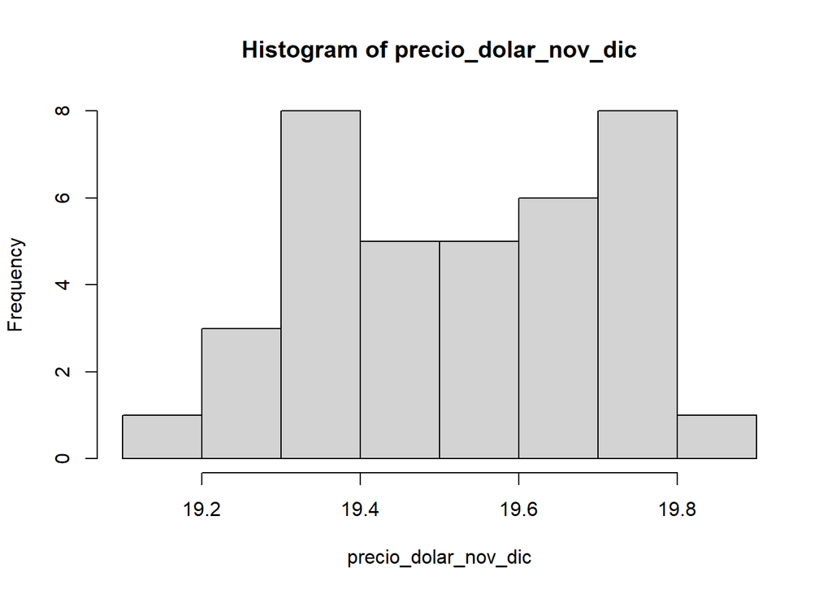

```r
precio_dolar_nov_dic <- c(19.643, 19.743, 19.792, 19.77, 19.748,
                          19.604, 19.51, 19.844, 19.763, 19.6126,
                          19.657, 19.746, 19.726, 19.374, 19.123,
                          19.251, 19.216, 19.295, 19.33, 19.367,
                          19.354, 19.419, 19.538, 19.435, 19.407,
                          19.338, 19.354, 19.339, 19.495, 19.31,
                          19.567, 19.513, 19.441, 19.501, 19.635,
                          19.65, 19.74)
hist(precio_dolar_nov_dic)
```

### 4.3.1. Agregar texto al histograma

Para agregar texto al histograma, se utiliza los parámetros “main” para el título del gráfico, “sub” para el subtítulo del gráfico, “xlab” nombre del eje x y “ylab” nombre del eje y. En el siguiente código se visualiza un histograma con texto:

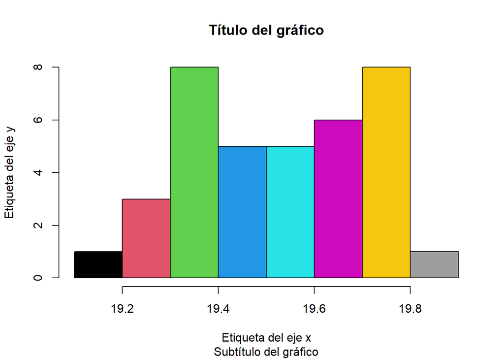

```r
hist(precio_dolar_nov_dic, main = "Título del gráfico",
     sub = "Subtítulo del gráfico",
     xlab = "Etiqueta del eje x", ylab = "Etiqueta del eje y",
     col = palette("Pastel 2"))
```

## 4.4. Función `pie()`

La función `pie()`, se utiliza para realizar diagramas de pastel. El primer argumento de esta función, son lo valores que demarcarán las divisiones del círculo que representa el 100% del área. Luego se indican los valores que determinarán la construcción de etiquetas. En el siguiente ejemplo se muestra un diagrama de pastel:

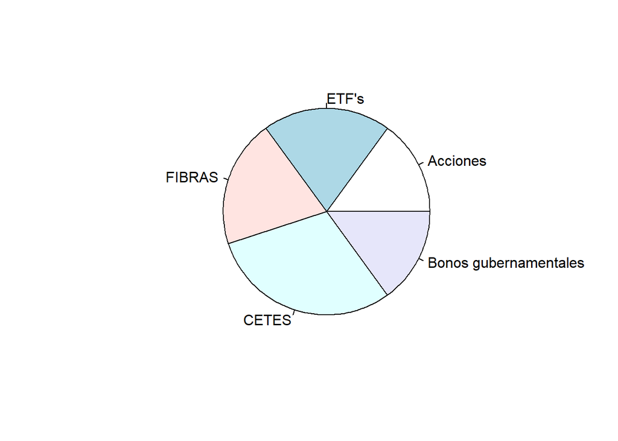

```r
porcentajes <- c(0.15,0.2,0.2,0.3,0.15) # Porcentajes asociados a cada instrumento de inversión
etiqueta_porcentajes <- c("Acciones","ETF's","FIBRAS","CETES",
                          "Bonos gubernamentales")

pie(porcentajes, labels = etiqueta_porcentajes)
```

### 4.4.1. Agregar texto a la gráfica

Para agregar texto a la gráfica, se utiliza los parámetros “main” para título del gráfico, “sub” para subtítulo del gráfico, “xlab” nombre del eje x y “ylab” nombre del eje y. En el siguiente código se visualiza un gráfico con texto.

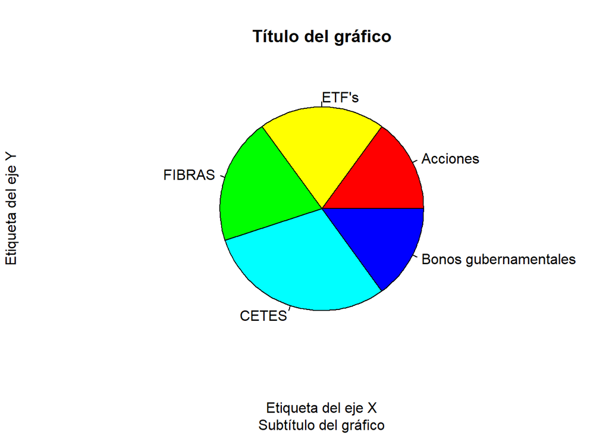

```r
pie(porcentajes, labels = etiqueta_porcentajes,
    main = "Título del gráfico",
    sub = "Subtítulo del gráfico", xlab = "Etiqueta del eje X",
    ylab = "Etiqueta del eje Y", col = rainbow(6))
```